# Practical 0

Francoise Cabada-Blanco

01/02/2022

For this first self-guided practical, you will need to first open RStudio. You can then open the R project by clicking on the top menu in **File** and within the drop-down menu select **Open Project…**

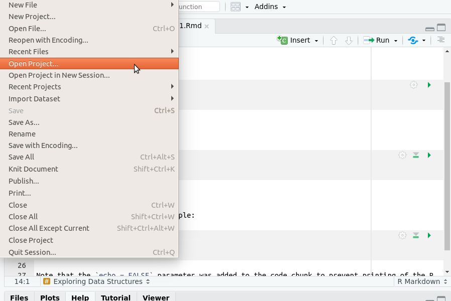

An R script file, named **Script_0_BasicR.R** should be now visible in one of the panes. Change the fields for *author* and *date* as appropriate. You will use one R Script file on each practical to document what you do.

The console keeps track of every action that is executes, so you will probably see at the bottom, a line with a message saying that a workspace has been loaded from a Directory path.

## Checking you are in the right place

As we read on the book, during these practicals your R Studio will work on a local directory. What that means is that everything that you do and want to save, will be saved in that folder where the Directory path points to. Likewise everything you might want to open in R, like a dataset, it needs to be in that folder, otherwise R will not be able to load it into R Studio.

A directory path is like an address that tells where a file lives. For example, if you saved a folder called Experimental Biology on your Documents and inside that folder you have one for Stats, its address, or directory path would be:

```
             C:/Home/YourUserName/Documents/Experimental Biology/Stats
```

If we are in the wrong place, we again have several options. The easiest one is to go to the top menu of R Studio window and click on *Session* then select from the drop-down menu the option *Set Working Directory* and choose *To Project Directory*

[figure not shown]

You can also set a specific working directory through the command line, using the function below. The argument you need to provide is the full path to the directory. So, for example:

```r
## setwd("C:/Home/YourUserName/Documents/Experimental Biology/Stats")
```

Now that you checked you are in the correct working directory, start coding!

Below are a series of short R codes that allow you to create, access, change and subset different objects in R.

Explore what they do by typing each of them into your Script and running the line. I strongly recommend not to copy-paste them. This can insert typos but also impedes you learning faster how to code in R. Remember to document your code in the Script file, adding as much information as you need to.

## Creating objects of different data structures

This second part of the practical is intended to let you play with the basic data structures that were described in the Moodle Book. The basic steps of progression are documented in the chunck of code below through comments.

### Vectors

```r
# Create a vector
myVector <- c(15, 21, 17, 25, 12, 51, 32, 12, 34)
# to see your vector
myVector

# getting information from your vector
# class or type of data structure or object
class(myVector)
#length or number of elements in the vector
length(myVector)
```

### Matrices

```r
# Create a matrix
# The basic syntax is: matrix(data, nrow, ncol, byrow, dimnames)

# Elements are arranged sequentially by row
myMatrix_byrow <- matrix(myVector, nrow= 3, byrow=TRUE)

# to see your matrix
myMatrix_byrow

# Elements are arranged sequentially by column
myMatrix_bycol <- matrix(myVector, nrow= 3, byrow=FALSE)

# to see your matrix
myMatrix_bycol

# No we provide information for the dimension attributes

# Define the column and row names.
rownames = c("row1", "row2", "row3")
colnames = c("col1", "col2", "col3")

# specify the attributes by adding the argument dimnames
myMatrix_withnames <- matrix(myVector, nrow = 3, byrow = TRUE, dimnames = list(rownames, colnames))

# to see your matrix
myMatrix_withnames

# getting information of the matrix
# size of your matrices
dim(myMatrix_byrow)
dimnames(myMatrix_withnames)

# class or type of data structure or object
class(myMatrix_bycol)
```

### Data Frames

Let us say myVector are the number of ATPs consumed by a full cycle of the number of ribulose-5-P epimerized to xylulose-5-P within the Pentose Phosphate Pathway in a period of time. This variable was measured on nine different thalli of a species of seaweed. That is thallus1, thallus2, thallus3…..thallus9. We have two types of elements: (1) the number of epimerized R5P, and (2) the seaweed. This requires a dataframe because matrices only store the same type of element.

```r
# we use the function dataframe and provide as arguments the names and valaues for each of the columns
myDataframe <- data.frame(
  seaweed= c("thallus1","thallus2","thallus3","thallus4","thallus5","thallus6","thallus7","thallus8","thallus9"),
  R5P= myVector)

# to see your dataframe
myDataframe

# to see the name of the columns of your dataset
colnames(myDataframe)

# we can change the names of the columns
colnames(myDataframe)<-c("thalli number","ribulose-5-P")

# check again to see if the changes were made correctly
colnames(myDataframe)

# Add a column to the dataframe
# create a vector that has a length equal to the columns of the dataframe
waterTemp <- c(15,15,15,21,21,21,28,28,28)

# we now bind the column to the dataset
myDataframe$waterTemp <- waterTemp

# check again to see if the changes were made correctly
myDataframe


# Add a row to the dataframe
# the row needs to have as many elements as columns in the dataframe

newrow <- c("thallus10", "29", "31")

# check the class
class(newrow)

# It is a vector of characters, including the numbers. Why do you think R coerced all elements to characters?

# The solution is to create a new dataframe with 1 row. But this needs to have the same column names

newrow <- data.frame("thallus10", 29, 31)

colnames(newrow)<-c("thalli number","ribulose-5-P", "waterTemp")

# and then bind both dataframes by row

myDataframe <- rbind.data.frame(myDataframe,newrow)

# check the row was added
print(myDataframe)
```

### Lists

As we read on the Moodle Book for this week, List are able to store not only different types of elements, but in fact, different types of objects. Most of the outputs that R will produce from running statistical tests will be in the form of lists. Although we are not going to manipulate many lists during the practicals, it is good that you know they exist, how to create one and further along this practical, how to slice it.

```r
# We create a list using the function list and providing the name of the different objects we want the list to contain.

myList <- list(myVector, myMatrix_withnames, myDataframe)

# to see the list
print(myList)

# Now that the list has been created, we can give names to the elements

names(myList) <- c("A vector", "A matrix", "A data-frame")

# we check the names were assigned
print(myList)

# Add element at the end of the list.
myList[4] <- "New element"

# we check the names were assigned
print(myList)

# Remove the last element.
myList[4] <- NULL

# we check the names were assigned
print(myList)
```

You can notice that we started to use the function print() so that the object’s elements are printed in the console. Although R does not require you to include this -typing the mane suffices- it is a good coding practice.

## Slicing and Subsetting

Slicing allow us to access elements within objects and to create subsets. below we cover some of the most basic ways to access the different objects we created above.

From this point on, you have to check what the specific piece of code you run did to the object. The reminder and code to do so, are no longer included.

### Vectors

```r
 # Returns the full vector
 myVector[]

 # Third value
 myVector[3]

 # Third value, simplified
 myVector[[3]]

 # Elements one to three
 myVector[1:3]

 # Second and fifth elements
 myVector[c(2, 5)]

 # Second element twice
 myVector[c(2, 2)]

 # All values except the fourth
 myVector[-4]

 # All values except the fourth and fifth
 myVector[-c(4, 5)]
 myVector[c(-4, -5)] # Equivalent

 # First, third, fourth and sixth values
 myVector[c(TRUE, FALSE, TRUE, TRUE, FALSE, TRUE, FALSE, FALSE, FALSE)]

 # Elements greater than 15
 myVector[myVector > 15]

 # With subset function
 subset(myVector, myVector > 15)
```

### Matrices

```r
# Access the element at 3rd column and 1st row.
print(myMatrix_withnames[1,3])

# Access the element at 2nd column and 3rd row.
print(myMatrix_withnames[3,2])

# Access only the  2nd row.
print(myMatrix_withnames[2,])

# Access only the 3rd column.
print(myMatrix_withnames[,3])
```

### Data frames

```r
# Extract a specific column
r5p <- myDataframe$`ribulose-5-P`

# Extract the second and third row

thallus2_3 <- myDataframe[2:3, ]

#
```

### Lists

```r
# Access the first element of the list.
print(myList[1])

# Access the thrid element. As it is also a list, all its elements will be printed.
print(myList[3])

# Access the list element using the name of the element.
print(myList$`A matrix`)
```